# Course Project - Assignment

Joly Tematio

July 21, 2019

## Course Project - Assignment on Activity Monitoring Data

We’ll start with an exploratory analysis and look how our dataset is structured.

```r
setwd("C:/Users/jolivette.tematio/Documents/Perso/R/Coursera/Rep.Research")
data <- read.csv(file = "activity.csv")
head(data)
```

```
  steps       date interval
1    NA 2012-10-01        0
2    NA 2012-10-01        5
3    NA 2012-10-01       10
4    NA 2012-10-01       15
5    NA 2012-10-01       20
6    NA 2012-10-01       25
```

```r
dim(data)
```

```
[1] 17568     3
```

```r
str(data)
```

```
'data.frame':   17568 obs. of  3 variables:
 $ steps   : int  NA NA NA NA NA NA NA NA NA NA ...
 $ date    : Factor w/ 61 levels "2012-10-01","2012-10-02",..: 1 1 1 1 1 1 1 1 1 1 ...
 $ interval: int  0 5 10 15 20 25 30 35 40 45 ...
```

```r
#cheking the missing values
missing_dt <- data[is.na(data$steps),]
dim(missing_dt)
```

```
[1] 2304    3
```

```r
sum(data$steps & data$date, na.rm = TRUE)
```

```
[1] 0
```

## I- What is mean total number of steps taken per day?

Data without the missing values

```r
dt2 <- data[!is.na(data$steps),]
```

Calculate the total number of steps taken per day

```r
total_number_steps <- with(data, tapply(steps,as.factor(data$date), sum, na.rm = T))
```

Make a histogram of the total number of steps taken each day

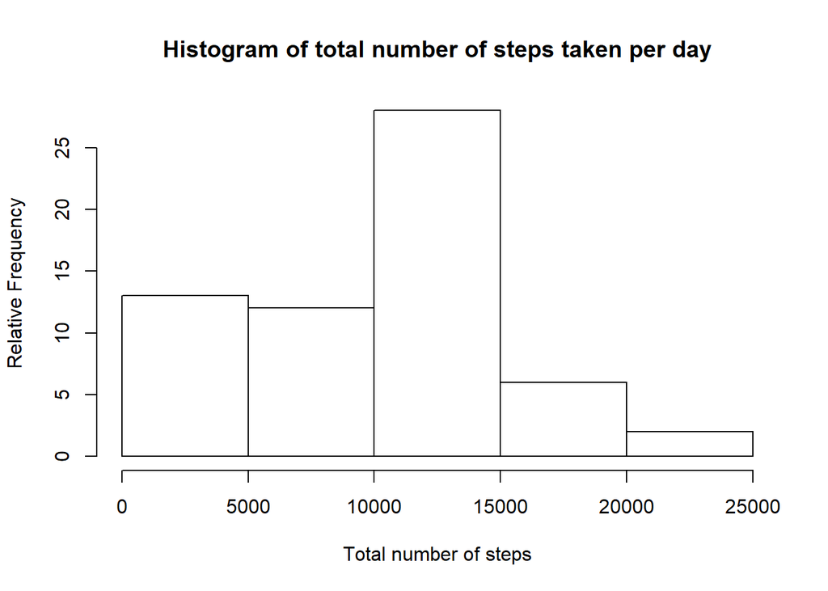

```r
hist(total_number_steps, main = "Histogram of total number of steps taken per day", xlab = "Total number of steps", ylab = "Relative Frequency")
```

Calculate and report the mean and median of the total number of steps taken per day

```r
summary(total_number_steps)
```

```
   Min. 1st Qu.  Median    Mean 3rd Qu.    Max.
      0    6778   10395    9354   12811   21194
```

## II- What is the average daily activity pattern?

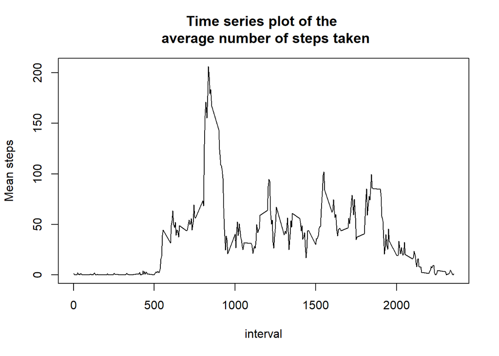

```r
mean_steps <- with(dt2, tapply(steps, dt2$interval, mean))
interval <- levels(as.factor(dt2$interval))
plot(interval, mean_steps, type = "l", main = "Time series plot of the \n average number of steps taken", xlab = "interval", ylab = "Mean steps")
```

## III- Imputing missing values

1- Determine and report the total number of missing values in the dataset (i.e. the total number of rows with NAs)

```r
length(missing_dt$steps)
```

```
[1] 2304
```

2- Devise a strategy for filling in all of the missing values in the dataset.

```r
mean_steps <- with(dt2, tapply(steps, dt2$interval, mean))
missing_dt$steps <- mean_steps
str(dt2)
```

```
'data.frame':   15264 obs. of  3 variables:
 $ steps   : int  0 0 0 0 0 0 0 0 0 0 ...
 $ date    : Factor w/ 61 levels "2012-10-01","2012-10-02",..: 2 2 2 2 2 2 2 2 2 2 ...
 $ interval: int  0 5 10 15 20 25 30 35 40 45 ...
```

2- Create a new dataset that is equal to the original dataset but with the missing data filled in.

```r
new_data <- rbind(dt2, missing_dt)
str(new_data)
```

```
'data.frame':   17568 obs. of  3 variables:
 $ steps   : num  0 0 0 0 0 0 0 0 0 0 ...
 $ date    : Factor w/ 61 levels "2012-10-01","2012-10-02",..: 2 2 2 2 2 2 2 2 2 2 ...
 $ interval: int  0 5 10 15 20 25 30 35 40 45 ...
```

```r
new_data <- new_data[order(new_data$date), ]
```

3- Make a histogram of the total number of steps taken each day and Calculate and report the mean and median total number of steps taken per day.

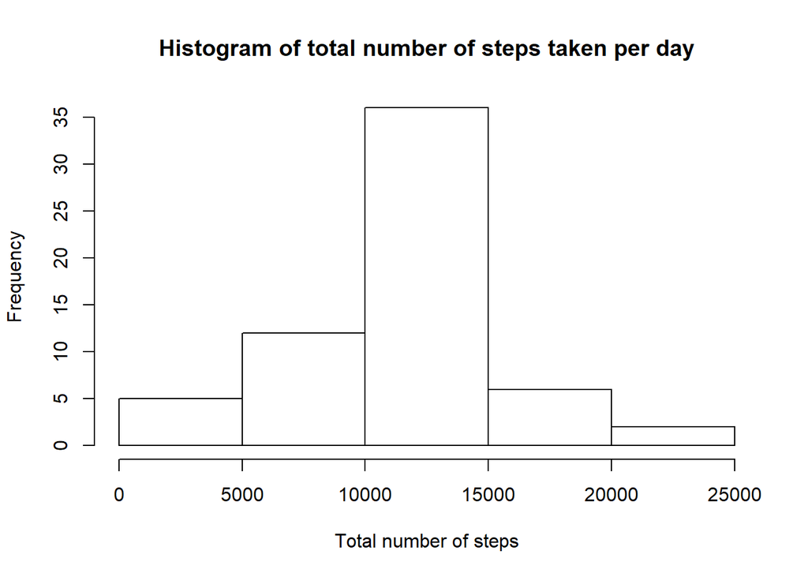

```r
total_number_steps2 <- with(new_data, tapply(steps, as.factor(new_data$date), sum))
#Make a histogram of the total number of steps taken each day
hist(total_number_steps2, main = "Histogram of total number of steps taken per day", xlab = "Total number of steps")
```

4- Calculate and report the mean and median of the total number of steps taken per day.

Mean and median total number of steps taken per day WITHOUT filling in the missing values

```r
summary(total_number_steps)
```

```
   Min. 1st Qu.  Median    Mean 3rd Qu.    Max.
      0    6778   10395    9354   12811   21194
```

Mean and median total number of steps taken per day WITH filling in the missing values

```r
summary(total_number_steps2)
```

```
   Min. 1st Qu.  Median    Mean 3rd Qu.    Max.
     41    9819   10766   10766   12811   21194
```

Yes, mean and median total number of steps taken per day for the filled in missing values differ from these of the origional dataset.

## IV - Are there differences in activity patterns between weekdays and weekends?

For this part the weekdays() function may be of some help here. Use the dataset with the filled-in missing values for this part.

1- Create a new factor variable in the dataset with two levels - “weekday” and “weekend” indicating whether a given date is a weekday or weekend day.

```r
new_data$days <- weekdays(as.Date(new_data$date))
# find weekend features in the dataset
weekend_feature <- grep("Saturday|Sunday", new_data$days, ignore.case = T)
# subset data of the weekend
weekend_dt<-  new_data[weekend_feature, ]
weekend_dt$weekday <- "weekend"

# subset data of the weekday
weekday_dt <- subset(new_data,new_data$days!=weekend_feature)
```

2- Create a new dataset containing 2 new variable “days” and weekday" days: indicates the days in the week weekday: indicate the days are at the “weekend” or “weekday”

```r
weekday_dt$weekday <- "weekday"
new_dt2 <- rbind(weekday_dt, weekend_dt)
```

3- Make a panel plot containing a time series plot (i.e. type = “l”) of the 5-minute interval (x-axis) and the average number of steps taken, averaged across all weekday days or weekend days (y-axis).

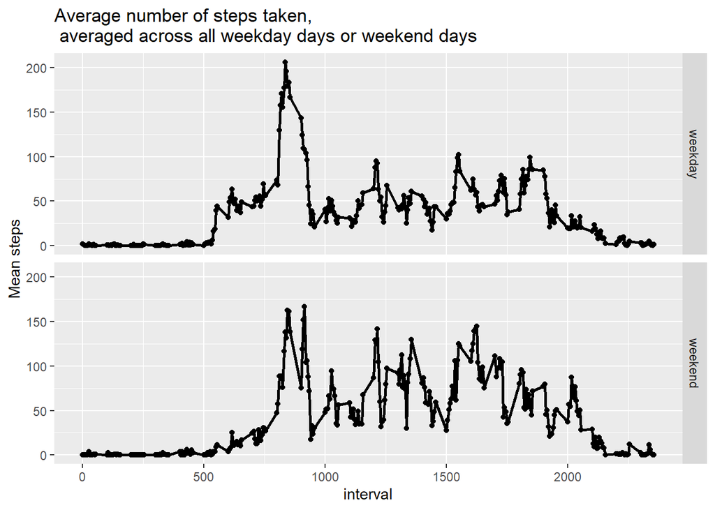

```r
library(ggplot2)
mean_number_steps <- aggregate(steps~ interval+weekday, new_dt2, mean)
g <- qplot(interval, steps, data = mean_number_steps, facets = weekday~.)
g + geom_line(size = 1) + ylab("Mean steps") + ggtitle("Average number of steps taken, \n averaged across all weekday days or weekend days ")
```

## V - Acknowledgement

Thank you very much for your effort to review my code!

## VI - References

*bullet 1 R Programming for Data Science, Roger D. Peng.* Exploratory Data Analyis with R, Roger D. Peng *Report Writing for Data Science in R, Roger D. Peng